# Enriching `glm` objects

[Ioannis Kosmidis](http://www.ucl.ac.uk/~ucakiko/)

2017-10-07

# Introduction

The [**enrichwith**](https://github.com/ikosmidis/enrichwith) R package provides the `enrich` method to enrich list-like R objects with new, relevant components. The resulting objects preserve their class, so all methods associated with them still apply.

This vignette is a demo of the available enrichment options for `glm` objects.

# Clotting data set

The following data set is provided in McCullagh and Nelder (1989 Section 8.4) and consists of observations on $n = 18$ mean clotting times of blood in seconds (`time`) for each combination of nine percentage concentrations of normal plasma (`conc`) and two lots of clotting agent (`lot`).

```r
clotting <- data.frame(conc = c(5,10,15,20,30,40,60,80,100,
                                5,10,15,20,30,40,60,80,100),
                       time = c(118, 58, 42, 35, 27, 25, 21, 19, 18,
                                69, 35, 26, 21, 18, 16, 13, 12, 12),
                       lot = factor(c(rep(1, 9), rep(2, 9))))
```

McCullagh and Nelder (1989 Section 8.4) fitted a series of nested generalized linear models assuming that the times are realisations of independent [Gamma](https://en.wikipedia.org/wiki/Gamma_distribution) random variables whose mean varies appropriately with concentration and lot. In particular, McCullagh and Nelder (1989) linked the inverse mean of the gamma random variables to the linear predictors `~ 1`, `~ log(conc)`, `~ log(conc) + lot`, `~ log(conc) * lot` and carried out an analysis of deviance to conclude that the `~ log(u) * lot` provides the best explanation of clotting times. The really close fit of that model to the data can be seen in the figure below.

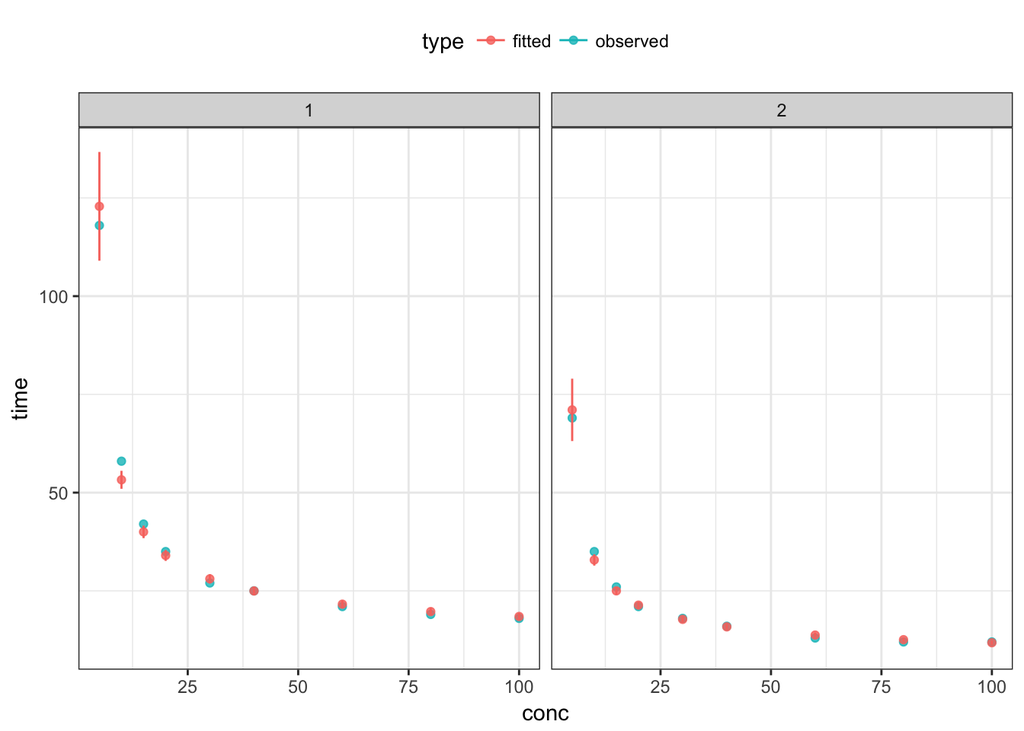

```r
library("ggplot2")
clottingML <- glm(time ~ log(conc) * lot, family = Gamma, data = clotting)
alpha <- 0.01
pr_out <- predict(clottingML, type = "response", se.fit = TRUE)
new_data <- clotting
new_data$time <- pr_out$fit
new_data$type <- "fitted"
clotting$type <- "observed"
all_data <- rbind(clotting, new_data)
new_data <- within(new_data, {
    low <- pr_out$fit - qnorm(1 - alpha/2) * pr_out$se.fit
    upp <- pr_out$fit + qnorm(1 - alpha/2) * pr_out$se.fit
})
ggplot(all_data) +
    geom_point(aes(conc, time, col = type), alpha = 0.8) +
    geom_segment(data = new_data, aes(x = conc, y = low, xend = conc, yend = upp, col = type)) +
    facet_grid(. ~ lot) +
    theme_bw() +
    theme(legend.position = "top")
```

# Key quantities in likelihood inference

## Score function

The score function is the gradient of the log-likelihood and is a key object for likelihood inference.

The **enrichwith** R package provides methods for the enrichment of `glm` objects with the corresponding score function. This can either be done by enriching the `glm` object with `auxiliary_functions` and then extracting the score function

```r
library("enrichwith")
enriched_clottingML <- enrich(clottingML, with = "auxiliary functions")
scores_clottingML <- enriched_clottingML$auxiliary_functions$score
```

or directly using the `get_score_function` convenience method

```r
scores_clottingML <- get_score_function(clottingML)
```

By definition, the score function has to have zero components when evaluated at the maximum likelihood estimates (only numerically zero here).

```r
scores_clottingML()
```

```
##    (Intercept)      log(conc)           lot2 log(conc):lot2     dispersion
##   1.227818e-05   2.253249e-05   6.113431e-07   1.548145e-06   1.647695e-09
## attr(,"coefficients")
##    (Intercept)      log(conc)           lot2 log(conc):lot2
##   -0.016554382    0.015343115   -0.007354088    0.008256099
## attr(,"dispersion")
##  dispersion
## 0.001632971
```

## Information matrix

Another key quantity in likelihood inference is the [expected information](https://en.wikipedia.org/wiki/Fisher_information).

The `auxiliary_functions` enrichment option of the `enrich` method enriches a `glm` object with a function for the evaluation of the expected information.

```r
info_clottingML <- enriched_clottingML$auxiliary_functions$information
```

and can also be computed directly using the `get_information_function` method

```r
info_clottingML <- get_information_function(clottingML)
```

One of the uses of the expected information is the calculation of standard errors for the model parameters. The `stats::summary.glm` function already does that for `glm` objects, estimating the dispersion parameter (if any) using Pearson residuals.

```r
summary_clottingML <- summary(clottingML)
```

Duly, `info_clottingML` returns (numerically) the same standard errors as the `summary` method does.

```r
summary_std_errors <- coef(summary_clottingML)[, "Std. Error"]
einfo <- info_clottingML(dispersion = summary_clottingML$dispersion)
all.equal(sqrt(diag(solve(einfo)))[1:4], summary_std_errors, tolerance = 1e-05)
```

```
## [1] TRUE
```

Another estimate of the standard errors results by the [observed information](https://en.wikipedia.org/wiki/Observed_information), which is the negative [Hessian matrix](https://en.wikipedia.org/wiki/Hessian_matrix) of the log-likelihood.

At least at the time of writting the current vignette, there appears to be no general implementation of the observed information for `glm` objects. I guess the reason for that is the dependence of the observed information on higher-order derivatives of the inverse link and variance functions, which are not readily available in base R.

**enrichwith** provides options for the enrichment of `link-glm` and `family` objects with such derivatives (see `?enrich.link-glm` and `?enrich.family` for details), and, based on those allows the enrichment of `glm` objects with a function to compute the observed information.

The observed and the expected information for the regression parameters coincide for GLMs with canonical link, like `clottingML`

```r
oinfo <- info_clottingML(dispersion = summary_clottingML$dispersion, type = "observed")
all.equal(oinfo[1:4, 1:4], einfo[1:4, 1:4])
```

```
## [1] TRUE
```

which is not generally true for a `glm` with a non-canonical link, as seen below.

```r
clottingML_log <- update(clottingML, family = Gamma("log"))
summary_clottingML_log <- summary(clottingML_log)
info_clottingML_log <- get_information_function(clottingML_log)
einfo_log <- info_clottingML_log(dispersion = summary_clottingML_log$dispersion, type = "expected")
oinfo_log <- info_clottingML_log(dispersion = summary_clottingML_log$dispersion, type = "observed")
round(einfo_log, 3)
```

```
##                (Intercept) log(conc)     lot2 log(conc):lot2 dispersion
## (Intercept)        757.804  2508.115  378.902       1254.058       0.00
## log(conc)         2508.115  8971.520 1254.058       4485.760       0.00
## lot2               378.902  1254.058  378.902       1254.058       0.00
## log(conc):lot2    1254.058  4485.760 1254.058       4485.760       0.00
## dispersion           0.000     0.000    0.000          0.000   16078.16
## attr(,"coefficients")
##    (Intercept)      log(conc)           lot2 log(conc):lot2
##     5.50322528    -0.60191618    -0.58447142     0.03448168
## attr(,"dispersion")
## [1] 0.02375284
```

```r
round(oinfo_log, 3)
```

```
##                (Intercept) log(conc)     lot2 log(conc):lot2 dispersion
## (Intercept)        757.804  2508.114  378.902       1254.057      0.000
## log(conc)         2508.114  9056.792 1254.057       4527.583     -0.041
## lot2               378.902  1254.057  378.902       1254.057      0.000
## log(conc):lot2    1254.057  4527.583 1254.057       4527.583     -0.018
## dispersion           0.000    -0.041    0.000         -0.018   7610.128
## attr(,"coefficients")
##    (Intercept)      log(conc)           lot2 log(conc):lot2
##     5.50322528    -0.60191618    -0.58447142     0.03448168
## attr(,"dispersion")
## [1] 0.02375284
```

## Score tests

We can now use `scores_clottingML` and `info_clottingML` to carry out [a score test](https://en.wikipedia.org/wiki/Score_test) to compare nested models.

If $l_\psi(\psi, \lambda)$ is the gradient of the log-likelihood with respect to $\psi$ evaluated at $\psi$ and $\lambda$, $i^{\psi\psi}(\psi, \lambda)$ is the $(\psi, \psi)$ block of the inverse of the expected information matrix, and $\hat\lambda_\psi$ is the maximum likelihood estimator of $\lambda$ for fixed $\psi$, then, assuming that the model is adequate
$$l_\psi(\psi, \hat\lambda_\psi)^\top i^{\psi\psi}(\psi,\hat\lambda_\psi) l_\psi(\psi, \hat\lambda_\psi)$$
has an asymptotic $\chi^2_{dim(\psi)}$ distribution.

```r
clottingML_nested <- update(clottingML, . ~ log(conc))
enriched_clottingML_nested <- enrich(clottingML_nested, with = "mle of dispersion")
coef_full <- coef(clottingML)
coef_hypothesis <- structure(rep(0, length(coef_full)), names = names(coef_full))
coef_hypothesis_short <- coef(enriched_clottingML_nested, model = "mean")
coef_hypothesis[names(coef_hypothesis_short)] <- coef_hypothesis_short
disp_hypothesis <- coef(enriched_clottingML_nested, model = "dispersion")
scores <- scores_clottingML(coef_hypothesis, disp_hypothesis)
info <- info_clottingML(coef_hypothesis, disp_hypothesis)
```

The object `enriched_clottingML_nested` inherits from `enriched_glm`, `glm` and `lm`, and, as illustrated above, **enrichwith** provides a corresponding `coef` method to extract the estimates for the mean regression parameters and/or the estimate for the dispersion parameter.

The score statiistic is then

```r
(score_statistic <- drop(scores%*%solve(info)%*%scores))
```

```
## [1] 17.15989
```

which gives a p-value of

```r
pchisq(score_statistic, 2, lower.tail = FALSE)
```

```
## [1] 0.000187835
```

For comparison, the Wald statistic for the same hypothesis is

```r
coef_full[3:4]%*%solve(solve(info)[3:4, 3:4])%*%coef_full[3:4]
```

```
##          [,1]
## [1,] 19.18963
```

and the log-likelihood ratio statistic is

```r
(deviance(clottingML_nested) - deviance(clottingML))/disp_hypothesis
```

```
## dispersion
##    17.6435
```

which is close to the score statistic

## Simulating from `glm` objects at parameter values

**enrichwith** also provides the `get_simulate_function` method for `glm` or `lm` objects. The `get_simulate_function` computes a function to simulate response vectors at /arbitrary/ values of the model parameters, which can be useful when setting up simulation experiments and for various inferential procedures (e.g. indirect inference).

For example, the following code chunk simulates three response vectors at the maximum likelihood estimates of the parameters for `clottingML`.

```r
simulate_clottingML <- get_simulate_function(clottingML)
simulate_clottingML(nsim = 3, seed = 123)
```

```
##        sim_1     sim_2     sim_3
## 1  119.99301 117.71976 124.77001
## 2   55.81195  53.03677  51.33030
## 3   37.29072  37.29519  39.83985
## 4   34.15268  32.39287  33.38394
## 5   30.02089  26.76743  27.99428
## 6   25.41892  24.63002  25.23102
## 7   20.50630  21.33982  20.69055
## 8   18.36304  19.61270  18.50062
## 9   19.39328  19.08656  17.67781
## 10  72.03656  72.99039  71.62121
## 11  33.36883  33.57407  33.34055
## 12  25.09187  24.91749  24.47527
## 13  20.87817  21.60344  23.25175
## 14  18.66966  16.86550  16.78601
## 15  16.35583  15.69062  16.01810
## 16  13.71021  13.65021  13.99123
## 17  12.32866  13.18895  12.59467
## 18  11.68437  11.25791  12.23057
```

The result is the same to what the `simulate` method returns

```r
simulate(clottingML, nsim = 3, seed = 123)
```

```
##        sim_1     sim_2     sim_3
## 1  119.99301 117.71976 124.77001
## 2   55.81195  53.03677  51.33030
## 3   37.29072  37.29519  39.83985
## 4   34.15268  32.39287  33.38394
## 5   30.02089  26.76743  27.99428
## 6   25.41892  24.63002  25.23102
## 7   20.50630  21.33982  20.69055
## 8   18.36304  19.61270  18.50062
## 9   19.39328  19.08656  17.67781
## 10  72.03656  72.99039  71.62121
## 11  33.36883  33.57407  33.34055
## 12  25.09187  24.91749  24.47527
## 13  20.87817  21.60344  23.25175
## 14  18.66966  16.86550  16.78601
## 15  16.35583  15.69062  16.01810
## 16  13.71021  13.65021  13.99123
## 17  12.32866  13.18895  12.59467
## 18  11.68437  11.25791  12.23057
```

but `simulate_clottingML` can also be used to simulate at any given parameter value

```r
coefficients <- c(0, 0.01, 0, 0.01)
dispersion <- 0.001
samples <- simulate_clottingML(coefficients = coefficients, dispersion = dispersion, nsim = 500000, seed = 123)
```

The empirical means and variances based on `samples` agree with the exact means and variances at `coefficients` and `dispersion`

```r
means <- 1/(model.matrix(clottingML) %*% coefficients)
variances <- dispersion * means^2
max(abs(rowMeans(samples) - means))
```

```
## [1] 0.004616079
```

```r
max(abs(apply(samples, 1, var) - variances))
```

```
## [1] 0.00792772
```

# pmodel, dmodel, qmodel

**enrichwith** also provides the `get_dmodel_function`, `get_pmodel_function` and `get_qmodel_function` methods, which can be used to evaluate densities or probability mass functions, distribution functions, and quantile functions, respectively at arbitrary parameter values and data settings.

For example, the following code chunk computes the density at the observations in the `clotting` data set under then maximum likelihood fit

```r
cML_dmodel <- get_dmodel_function(clottingML)
cML_dmodel()
```

```
##          1          2          3          4          5          6
## 0.05114789 0.01729857 0.11264667 0.21780853 0.23240296 0.39469095
##          7          8          9         10         11         12
## 0.36529389 0.33731787 0.44320377 0.11009363 0.08136892 0.23566642
##         13         14         15         16         17         18
## 0.42776887 0.51483860 0.59720662 0.29329145 0.42214857 0.75181329
## attr(,"coefficients")
##    (Intercept)      log(conc)           lot2 log(conc):lot2
##   -0.016554382    0.015343115   -0.007354088    0.008256099
## attr(,"dispersion")
##  dispersion
## 0.001632971
```

We can also compute the densities at user-supplied parameter values

```r
cML_dmodel(coefficients = c(-0.01, 0.02, -0.01, 0), dispersion = 0.1)
```

```
##            1            2            3            4            5
## 1.504831e-05 6.298754e-04 2.784455e-03 5.394485e-03 1.427986e-02
##            6            7            8            9           10
## 1.392561e-02 2.241253e-02 2.775377e-02 2.904231e-02 1.573806e-02
##           11           12           13           14           15
## 3.429823e-02 4.497386e-02 5.143328e-02 6.281910e-02 7.022318e-02
##           16           17           18
## 7.721225e-02 8.508033e-02 9.434798e-02
## attr(,"coefficients")
## [1] -0.01  0.02 -0.01  0.00
## attr(,"dispersion")
## [1] 0.1
```

or even at different data points

```r
new_data <- data.frame(conc = 5:10, time = 50:45, lot = factor(c(1, 1, 1, 2, 2, 2)))
cML_dmodel(data = new_data, coefficients = c(-0.01, 0.02, -0.01, 0), dispersion = 0.1)
```

```
##          1          2          3          4          5          6
## 0.02366298 0.01889204 0.01428215 0.02659079 0.02591742 0.02433105
## attr(,"coefficients")
## [1] -0.01  0.02 -0.01  0.00
## attr(,"dispersion")
## [1] 0.1
```

We can also compute cumulative probabilities and quantile functions. So

```r
cML_qmodel <- get_qmodel_function(clottingML)
cML_pmodel <- get_pmodel_function(clottingML)
probs <- cML_pmodel(data = new_data, coefficients = c(-0.01, 0.02, -0.01, 0), dispersion = 0.1)
cML_qmodel(probs, data = new_data, coefficients = c(-0.01, 0.02, -0.01, 0), dispersion = 0.1)
```

```
##  1  2  3  4  5  6
## 50 49 48 47 46 45
## attr(,"coefficients")
## [1] -0.01  0.02 -0.01  0.00
## attr(,"dispersion")
## [1] 0.1
```

returns `new_data$time`.

For example the fitted densities when `(conc, lot)` is `c(15, 1)`, `c(15, 2)`, `c(40, 1)` or `c(40, 2)` are

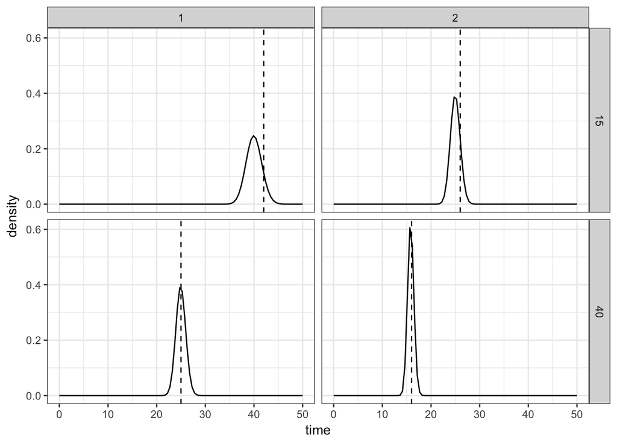

```r
new_data <- expand.grid(conc = c(15, 40),
                        lot = factor(1:2),
                        time = seq(0, 50, length = 100))
new_data$density <- cML_dmodel(new_data)
ggplot(data = new_data) +
    geom_line(aes(time, density)) + facet_grid(conc ~ lot) +
    theme_bw() +
    geom_vline(data = clotting[c(3, 6, 12, 15), ], aes(xintercept = time), lty = 2)
```

The dashed vertical lines are the observed values of time for the `(conc, lot)` combinations in the figure.

# `enriched_glm`

**enrichwith** provides a wrapper to the `glm` interface that results directly in `enriched_glm` objects that carry all the components described above. For example,

```r
enriched_clottingML <- enriched_glm(time ~ log(conc) * lot, family = Gamma, data = clotting)
names(enriched_clottingML$auxiliary_functions)
```

```
## [1] "score"       "information" "bias"        "simulate"    "dmodel"
## [6] "pmodel"      "qmodel"
```

```r
enriched_clottingML$score_mle
```

```
##    (Intercept)      log(conc)           lot2 log(conc):lot2     dispersion
##   1.227818e-05   2.253249e-05   6.113431e-07   1.548145e-06   1.647695e-09
## attr(,"coefficients")
##    (Intercept)      log(conc)           lot2 log(conc):lot2
##   -0.016554382    0.015343115   -0.007354088    0.008256099
## attr(,"dispersion")
##  dispersion
## 0.001632971
```

```r
enriched_clottingML$expected_information_mle
```

```
##                (Intercept) log(conc)     lot2 log(conc):lot2 dispersion
## (Intercept)       19327145  40768701  5060148       10887183          0
## log(conc)         40768701  98046714 10887183       26762283          0
## lot2               5060148  10887183  5060148       10887183          0
## log(conc):lot2    10887183  26762283 10887183       26762283          0
## dispersion               0         0        0              0    3376930
## attr(,"coefficients")
##    (Intercept)      log(conc)           lot2 log(conc):lot2
##   -0.016554382    0.015343115   -0.007354088    0.008256099
## attr(,"dispersion")
##  dispersion
## 0.001632971
```

```r
enriched_clottingML$observed_information_mle
```

```
##                 (Intercept)    log(conc)         lot2 log(conc):lot2
## (Intercept)    1.932714e+07 4.076870e+07 5.060148e+06   1.088718e+07
## log(conc)      4.076870e+07 9.804671e+07 1.088718e+07   2.676228e+07
## lot2           5.060148e+06 1.088718e+07 5.060148e+06   1.088718e+07
## log(conc):lot2 1.088718e+07 2.676228e+07 1.088718e+07   2.676228e+07
## dispersion     7.518920e-03 1.379847e-02 3.743748e-04   9.480544e-04
##                  dispersion
## (Intercept)    7.518920e-03
## log(conc)      1.379847e-02
## lot2           3.743748e-04
## log(conc):lot2 9.480544e-04
## dispersion     3.376930e+06
## attr(,"coefficients")
##    (Intercept)      log(conc)           lot2 log(conc):lot2
##   -0.016554382    0.015343115   -0.007354088    0.008256099
## attr(,"dispersion")
##  dispersion
## 0.001632971
```

```r
enriched_clottingML$bias_mle
```

```
##    (Intercept)      log(conc)           lot2 log(conc):lot2     dispersion
##   1.335333e-05  -1.616492e-06   9.431631e-06  -1.339775e-06  -3.627343e-04
## attr(,"coefficients")
##    (Intercept)      log(conc)           lot2 log(conc):lot2
##   -0.016554382    0.015343115   -0.007354088    0.008256099
## attr(,"dispersion")
##  dispersion
## 0.001632971
```

```r
enriched_clottingML$dispersion_mle
```

```
##  dispersion
## 0.001632971
```

# Links to other resources

The vignette [bias](https://CRAN.R-project.org/package=enrichwith/vignettes/bias.html) of **enrichwith** describes how to use the `auxiliary_functions` to reduce the bias of the maximum likelihood estimator for generalized linear models.

# References

McCullagh, P., and J. A. Nelder. 1989. *Generalized Linear Models*. 2nd ed. London: Chapman; Hall.